# Risk Factor Analysis

## Outcome Variable

**Outcome Variable:** ever_wasted

## Predictor Variables

**Intervention Variable:** earlybf

**Adjustment Set:**

- arm
- sex
- W_mage
- meducyrs
- feducyrs
- hhwealth_quart
- hfoodsec
- W_mhtcm
- W_mwtkg
- W_mbmi
- vagbrth
- W_gagebrth
- W_birthwt
- W_birthlen
- W_nrooms
- W_nchldlt5
- brthmon
- W_parity
- impfloor
- impsan
- safeh20
- delta_W_mage
- delta_meducyrs
- delta_feducyrs
- delta_hhwealth_quart
- delta_hfoodsec
- delta_W_mhtcm
- delta_W_mwtkg
- delta_W_mbmi
- delta_vagbrth
- delta_W_gagebrth
- delta_W_birthwt
- delta_W_birthlen
- delta_W_nrooms
- delta_W_nchldlt5
- delta_brthmon
- delta_W_parity
- delta_impfloor
- delta_impsan
- delta_safeh20

## Stratifying Variables

The analysis was stratified on these variable(s):

- agecat
- studyid
- country

## Data Summary

| agecat | studyid | country | earlybf | ever_wasted | n_cell | n |
| --- | --- | --- | --- | --- | --- | --- |
| 0-24 months (no birth wast) | EE | PAKISTAN | 1 | 0 | 33 | 366 |
| 0-24 months (no birth wast) | EE | PAKISTAN | 1 | 1 | 35 | 366 |
| 0-24 months (no birth wast) | EE | PAKISTAN | 0 | 0 | 137 | 366 |
| 0-24 months (no birth wast) | EE | PAKISTAN | 0 | 1 | 161 | 366 |
| 0-24 months (no birth wast) | GMS-Nepal | NEPAL | 1 | 0 | 95 | 599 |
| 0-24 months (no birth wast) | GMS-Nepal | NEPAL | 1 | 1 | 77 | 599 |
| 0-24 months (no birth wast) | GMS-Nepal | NEPAL | 0 | 0 | 209 | 599 |
| 0-24 months (no birth wast) | GMS-Nepal | NEPAL | 0 | 1 | 218 | 599 |
| 0-24 months (no birth wast) | JiVitA-3 | BANGLADESH | 1 | 0 | 122 | 26458 |
| 0-24 months (no birth wast) | JiVitA-3 | BANGLADESH | 1 | 1 | 21 | 26458 |
| 0-24 months (no birth wast) | JiVitA-3 | BANGLADESH | 0 | 0 | 21842 | 26458 |
| 0-24 months (no birth wast) | JiVitA-3 | BANGLADESH | 0 | 1 | 4473 | 26458 |
| 0-24 months (no birth wast) | JiVitA-4 | BANGLADESH | 1 | 0 | 2528 | 5396 |
| 0-24 months (no birth wast) | JiVitA-4 | BANGLADESH | 1 | 1 | 886 | 5396 |
| 0-24 months (no birth wast) | JiVitA-4 | BANGLADESH | 0 | 0 | 1477 | 5396 |
| 0-24 months (no birth wast) | JiVitA-4 | BANGLADESH | 0 | 1 | 505 | 5396 |
| 0-24 months (no birth wast) | MAL-ED | BANGLADESH | 1 | 0 | 128 | 262 |
| 0-24 months (no birth wast) | MAL-ED | BANGLADESH | 1 | 1 | 33 | 262 |
| 0-24 months (no birth wast) | MAL-ED | BANGLADESH | 0 | 0 | 77 | 262 |
| 0-24 months (no birth wast) | MAL-ED | BANGLADESH | 0 | 1 | 24 | 262 |
| 0-24 months (no birth wast) | MAL-ED | BRAZIL | 1 | 0 | 103 | 233 |
| 0-24 months (no birth wast) | MAL-ED | BRAZIL | 1 | 1 | 5 | 233 |
| 0-24 months (no birth wast) | MAL-ED | BRAZIL | 0 | 0 | 117 | 233 |
| 0-24 months (no birth wast) | MAL-ED | BRAZIL | 0 | 1 | 8 | 233 |
| 0-24 months (no birth wast) | MAL-ED | INDIA | 1 | 0 | 90 | 245 |
| 0-24 months (no birth wast) | MAL-ED | INDIA | 1 | 1 | 56 | 245 |
| 0-24 months (no birth wast) | MAL-ED | INDIA | 0 | 0 | 64 | 245 |
| 0-24 months (no birth wast) | MAL-ED | INDIA | 0 | 1 | 35 | 245 |
| 0-24 months (no birth wast) | MAL-ED | NEPAL | 1 | 0 | 79 | 239 |
| 0-24 months (no birth wast) | MAL-ED | NEPAL | 1 | 1 | 18 | 239 |

[output cut: 138 more lines]

The following strata were considered:

- agecat: 0-24 months (no birth wast), studyid: EE, country: PAKISTAN
- agecat: 0-24 months (no birth wast), studyid: GMS-Nepal, country: NEPAL
- agecat: 0-24 months (no birth wast), studyid: JiVitA-3, country: BANGLADESH
- agecat: 0-24 months (no birth wast), studyid: JiVitA-4, country: BANGLADESH
- agecat: 0-24 months (no birth wast), studyid: MAL-ED, country: BANGLADESH
- agecat: 0-24 months (no birth wast), studyid: MAL-ED, country: BRAZIL
- agecat: 0-24 months (no birth wast), studyid: MAL-ED, country: INDIA
- agecat: 0-24 months (no birth wast), studyid: MAL-ED, country: NEPAL
- agecat: 0-24 months (no birth wast), studyid: MAL-ED, country: PERU
- agecat: 0-24 months (no birth wast), studyid: MAL-ED, country: SOUTH AFRICA
- agecat: 0-24 months (no birth wast), studyid: MAL-ED, country: TANZANIA, UNITED REPUBLIC OF
- agecat: 0-24 months (no birth wast), studyid: NIH-Crypto, country: BANGLADESH
- agecat: 0-24 months (no birth wast), studyid: SAS-CompFeed, country: INDIA
- agecat: 0-24 months (no birth wast), studyid: ZVITAMBO, country: ZIMBABWE
- agecat: 0-6 months (no birth wast), studyid: EE, country: PAKISTAN
- agecat: 0-6 months (no birth wast), studyid: GMS-Nepal, country: NEPAL
- agecat: 0-6 months (no birth wast), studyid: JiVitA-3, country: BANGLADESH
- agecat: 0-6 months (no birth wast), studyid: JiVitA-4, country: BANGLADESH
- agecat: 0-6 months (no birth wast), studyid: MAL-ED, country: BANGLADESH
- agecat: 0-6 months (no birth wast), studyid: MAL-ED, country: BRAZIL
- agecat: 0-6 months (no birth wast), studyid: MAL-ED, country: INDIA
- agecat: 0-6 months (no birth wast), studyid: MAL-ED, country: NEPAL
- agecat: 0-6 months (no birth wast), studyid: MAL-ED, country: PERU
- agecat: 0-6 months (no birth wast), studyid: MAL-ED, country: SOUTH AFRICA
- agecat: 0-6 months (no birth wast), studyid: MAL-ED, country: TANZANIA, UNITED REPUBLIC OF
- agecat: 0-6 months (no birth wast), studyid: NIH-Crypto, country: BANGLADESH
- agecat: 0-6 months (no birth wast), studyid: SAS-CompFeed, country: INDIA
- agecat: 0-6 months (no birth wast), studyid: ZVITAMBO, country: ZIMBABWE
- agecat: 6-24 months, studyid: EE, country: PAKISTAN
- agecat: 6-24 months, studyid: GMS-Nepal, country: NEPAL
- agecat: 6-24 months, studyid: JiVitA-3, country: BANGLADESH
- agecat: 6-24 months, studyid: JiVitA-4, country: BANGLADESH
- agecat: 6-24 months, studyid: MAL-ED, country: BANGLADESH
- agecat: 6-24 months, studyid: MAL-ED, country: BRAZIL
- agecat: 6-24 months, studyid: MAL-ED, country: INDIA
- agecat: 6-24 months, studyid: MAL-ED, country: NEPAL
- agecat: 6-24 months, studyid: MAL-ED, country: PERU
- agecat: 6-24 months, studyid: MAL-ED, country: SOUTH AFRICA
- agecat: 6-24 months, studyid: MAL-ED, country: TANZANIA, UNITED REPUBLIC OF
- agecat: 6-24 months, studyid: NIH-Crypto, country: BANGLADESH
- agecat: 6-24 months, studyid: SAS-CompFeed, country: INDIA
- agecat: 6-24 months, studyid: ZVITAMBO, country: ZIMBABWE

### Dropped Strata

Some strata were dropped due to rare outcomes:

- agecat: 0-24 months (no birth wast), studyid: MAL-ED, country: PERU
- agecat: 0-24 months (no birth wast), studyid: MAL-ED, country: TANZANIA, UNITED REPUBLIC OF
- agecat: 0-6 months (no birth wast), studyid: MAL-ED, country: BRAZIL
- agecat: 0-6 months (no birth wast), studyid: MAL-ED, country: PERU
- agecat: 0-6 months (no birth wast), studyid: MAL-ED, country: SOUTH AFRICA
- agecat: 0-6 months (no birth wast), studyid: MAL-ED, country: TANZANIA, UNITED REPUBLIC OF
- agecat: 0-6 months (no birth wast), studyid: NIH-Crypto, country: BANGLADESH
- agecat: 6-24 months, studyid: MAL-ED, country: BRAZIL
- agecat: 6-24 months, studyid: MAL-ED, country: PERU
- agecat: 6-24 months, studyid: MAL-ED, country: TANZANIA, UNITED REPUBLIC OF

## Methods Detail

We’re interested in the causal parameters $E[Y_a]$ for all values of $a \in \mathcal{A}$. These parameters represent the mean outcome if, possibly contrary to fact, we intervened to set all units to have $A=a$. Under the randomization and positivity assumptions, these are identified by the statistical parameters $\psi_a=E_W[E_{Y|A,W}(Y|A=a,W)]$. In addition, we’re interested in the mean of $Y$, $E[Y]$ under no intervention (the observed mean). We will estimate these parameters by using SuperLearner to fit the relevant likelihood factors – $E_{Y|A,W}(Y|A=a,W)$ and $p(A=a|W)$, and then updating our likelihood fit using a joint TMLE.

For unadjusted analyses ($W=\{\}$), initial likelihoods were estimated using Lrnr_glm to estimate the simple $E(Y|A)$ and Lrnr_mean to estimate $p(A)$. For adjusted analyses, a small library containing Lrnr_glmnet, Lrnr_xgboost, and Lrnr_mean was used.

Having estimated these parameters, we will then use the delta method to estimate relative risks and attributable risks relative to a prespecified baseline level of $A$.

# Results Detail

## Results Plots

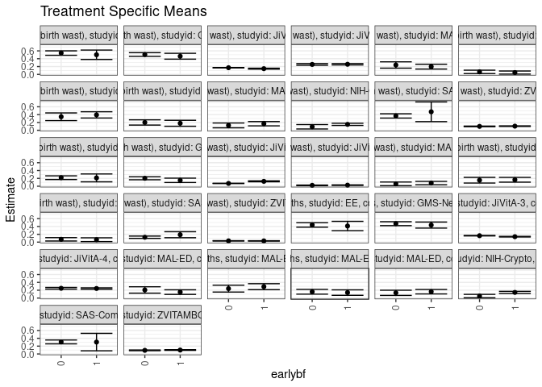

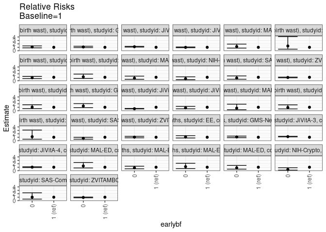

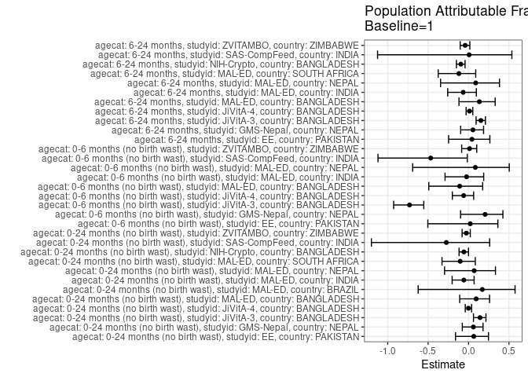

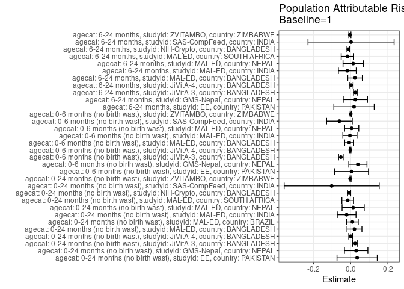

## Results Table

### Parameter: TSM

| agecat | studyid | country | intervention_level | baseline_level | estimate | ci_lower | ci_upper |
| --- | --- | --- | --- | --- | --- | --- | --- |
| 0-24 months (no birth wast) | EE | PAKISTAN | 1 | NA | 0.5006563 | 0.3808809 | 0.6204316 |
| 0-24 months (no birth wast) | EE | PAKISTAN | 0 | NA | 0.5438842 | 0.4872901 | 0.6004784 |
| 0-24 months (no birth wast) | GMS-Nepal | NEPAL | 1 | NA | 0.4629329 | 0.3884078 | 0.5374579 |
| 0-24 months (no birth wast) | GMS-Nepal | NEPAL | 0 | NA | 0.5063344 | 0.4592229 | 0.5534459 |
| 0-24 months (no birth wast) | JiVitA-3 | BANGLADESH | 1 | NA | 0.1457445 | 0.1331901 | 0.1582989 |
| 0-24 months (no birth wast) | JiVitA-3 | BANGLADESH | 0 | NA | 0.1699800 | 0.1645569 | 0.1754032 |
| 0-24 months (no birth wast) | JiVitA-4 | BANGLADESH | 1 | NA | 0.2578802 | 0.2401658 | 0.2755945 |
| 0-24 months (no birth wast) | JiVitA-4 | BANGLADESH | 0 | NA | 0.2537736 | 0.2324372 | 0.2751099 |
| 0-24 months (no birth wast) | MAL-ED | BANGLADESH | 1 | NA | 0.1970236 | 0.1355048 | 0.2585423 |
| 0-24 months (no birth wast) | MAL-ED | BANGLADESH | 0 | NA | 0.2394944 | 0.1588076 | 0.3201812 |
| 0-24 months (no birth wast) | MAL-ED | BRAZIL | 1 | NA | 0.0462963 | 0.0065817 | 0.0860109 |
| 0-24 months (no birth wast) | MAL-ED | BRAZIL | 0 | NA | 0.0640000 | 0.0210013 | 0.1069987 |
| 0-24 months (no birth wast) | MAL-ED | INDIA | 1 | NA | 0.3929527 | 0.3131887 | 0.4727167 |
| 0-24 months (no birth wast) | MAL-ED | INDIA | 0 | NA | 0.3454790 | 0.2479875 | 0.4429705 |
| 0-24 months (no birth wast) | MAL-ED | NEPAL | 1 | NA | 0.1789312 | 0.1027724 | 0.2550901 |
| 0-24 months (no birth wast) | MAL-ED | NEPAL | 0 | NA | 0.2000468 | 0.1333029 | 0.2667906 |
| 0-24 months (no birth wast) | MAL-ED | SOUTH AFRICA | 1 | NA | 0.1677007 | 0.1129039 | 0.2224974 |
| 0-24 months (no birth wast) | MAL-ED | SOUTH AFRICA | 0 | NA | 0.1243692 | 0.0631827 | 0.1855557 |
| 0-24 months (no birth wast) | NIH-Crypto | BANGLADESH | 1 | NA | 0.1513761 | 0.1238887 | 0.1788636 |
| 0-24 months (no birth wast) | NIH-Crypto | BANGLADESH | 0 | NA | 0.0900000 | 0.0338722 | 0.1461278 |
| 0-24 months (no birth wast) | SAS-CompFeed | INDIA | 1 | NA | 0.4725174 | 0.2208495 | 0.7241852 |
| 0-24 months (no birth wast) | SAS-CompFeed | INDIA | 0 | NA | 0.3669078 | 0.3124764 | 0.4213391 |
| 0-24 months (no birth wast) | ZVITAMBO | ZIMBABWE | 1 | NA | 0.1056348 | 0.0980359 | 0.1132336 |
| 0-24 months (no birth wast) | ZVITAMBO | ZIMBABWE | 0 | NA | 0.0999659 | 0.0919535 | 0.1079784 |
| 0-6 months (no birth wast) | EE | PAKISTAN | 1 | NA | 0.2123984 | 0.1116950 | 0.3131018 |
| 0-6 months (no birth wast) | EE | PAKISTAN | 0 | NA | 0.2179618 | 0.1708323 | 0.2650913 |
| 0-6 months (no birth wast) | GMS-Nepal | NEPAL | 1 | NA | 0.1501689 | 0.0945284 | 0.2058094 |
| 0-6 months (no birth wast) | GMS-Nepal | NEPAL | 0 | NA | 0.2028660 | 0.1641140 | 0.2416179 |
| 0-6 months (no birth wast) | JiVitA-3 | BANGLADESH | 1 | NA | 0.1243299 | 0.1122893 | 0.1363706 |
| 0-6 months (no birth wast) | JiVitA-3 | BANGLADESH | 0 | NA | 0.0716158 | 0.0678748 | 0.0753567 |
| 0-6 months (no birth wast) | JiVitA-4 | BANGLADESH | 1 | NA | 0.0271621 | 0.0209661 | 0.0333582 |
| 0-6 months (no birth wast) | JiVitA-4 | BANGLADESH | 0 | NA | 0.0224370 | 0.0149083 | 0.0299658 |
| 0-6 months (no birth wast) | MAL-ED | BANGLADESH | 1 | NA | 0.0807453 | 0.0385810 | 0.1229097 |
| 0-6 months (no birth wast) | MAL-ED | BANGLADESH | 0 | NA | 0.0600000 | 0.0133640 | 0.1066360 |
| 0-6 months (no birth wast) | MAL-ED | INDIA | 1 | NA | 0.1643324 | 0.1035645 | 0.2251004 |
| 0-6 months (no birth wast) | MAL-ED | INDIA | 0 | NA | 0.1534293 | 0.0813133 | 0.2255453 |
| 0-6 months (no birth wast) | MAL-ED | NEPAL | 1 | NA | 0.0618557 | 0.0138155 | 0.1098959 |
| 0-6 months (no birth wast) | MAL-ED | NEPAL | 0 | NA | 0.0714286 | 0.0286776 | 0.1141795 |
| 0-6 months (no birth wast) | SAS-CompFeed | INDIA | 1 | NA | 0.1890047 | 0.1120398 | 0.2659695 |
| 0-6 months (no birth wast) | SAS-CompFeed | INDIA | 0 | NA | 0.1253717 | 0.0960253 | 0.1547180 |
| 0-6 months (no birth wast) | ZVITAMBO | ZIMBABWE | 1 | NA | 0.0316867 | 0.0273470 | 0.0360264 |
| 0-6 months (no birth wast) | ZVITAMBO | ZIMBABWE | 0 | NA | 0.0325402 | 0.0277303 | 0.0373501 |
| 6-24 months | EE | PAKISTAN | 1 | NA | 0.4115638 | 0.2922773 | 0.5308502 |
| 6-24 months | EE | PAKISTAN | 0 | NA | 0.4393069 | 0.3826508 | 0.4959631 |
| 6-24 months | GMS-Nepal | NEPAL | 1 | NA | 0.4354749 | 0.3581296 | 0.5128201 |
| 6-24 months | GMS-Nepal | NEPAL | 0 | NA | 0.4708398 | 0.4207460 | 0.5209337 |
| 6-24 months | JiVitA-3 | BANGLADESH | 1 | NA | 0.1388889 | 0.1308343 | 0.1469435 |
| 6-24 months | JiVitA-3 | BANGLADESH | 0 | NA | 0.1640693 | 0.1577997 | 0.1703388 |
| 6-24 months | JiVitA-4 | BANGLADESH | 1 | NA | 0.2442600 | 0.2265317 | 0.2619882 |
| 6-24 months | JiVitA-4 | BANGLADESH | 0 | NA | 0.2491433 | 0.2275631 | 0.2707236 |
| 6-24 months | MAL-ED | BANGLADESH | 1 | NA | 0.1521506 | 0.0936478 | 0.2106533 |
| 6-24 months | MAL-ED | BANGLADESH | 0 | NA | 0.2065477 | 0.1252128 | 0.2878825 |
| 6-24 months | MAL-ED | INDIA | 1 | NA | 0.2902412 | 0.2140640 | 0.3664184 |
| 6-24 months | MAL-ED | INDIA | 0 | NA | 0.2411481 | 0.1531363 | 0.3291599 |
| 6-24 months | MAL-ED | NEPAL | 1 | NA | 0.1395882 | 0.0700434 | 0.2091329 |
| 6-24 months | MAL-ED | NEPAL | 0 | NA | 0.1605875 | 0.0994139 | 0.2217611 |
| 6-24 months | MAL-ED | SOUTH AFRICA | 1 | NA | 0.1623817 | 0.1053952 | 0.2193682 |
| 6-24 months | MAL-ED | SOUTH AFRICA | 0 | NA | 0.1337556 | 0.0674447 | 0.2000666 |
| 6-24 months | NIH-Crypto | BANGLADESH | 1 | NA | 0.1439873 | 0.1165975 | 0.1713772 |
| 6-24 months | NIH-Crypto | BANGLADESH | 0 | NA | 0.0510204 | 0.0074258 | 0.0946151 |
| 6-24 months | SAS-CompFeed | INDIA | 1 | NA | 0.3037327 | 0.0814133 | 0.5260522 |
| 6-24 months | SAS-CompFeed | INDIA | 0 | NA | 0.3075827 | 0.2587008 | 0.3564646 |
| 6-24 months | ZVITAMBO | ZIMBABWE | 1 | NA | 0.1006311 | 0.0922417 | 0.1090206 |
| 6-24 months | ZVITAMBO | ZIMBABWE | 0 | NA | 0.0929853 | 0.0842768 | 0.1016938 |

### Parameter: E(Y)

| agecat | studyid | country | intervention_level | baseline_level | estimate | ci_lower | ci_upper |
| --- | --- | --- | --- | --- | --- | --- | --- |
| 0-24 months (no birth wast) | EE | PAKISTAN | NA | NA | 0.5355191 | 0.4843541 | 0.5866841 |
| 0-24 months (no birth wast) | GMS-Nepal | NEPAL | NA | NA | 0.4924875 | 0.4524176 | 0.5325574 |
| 0-24 months (no birth wast) | JiVitA-3 | BANGLADESH | NA | NA | 0.1698541 | 0.1645584 | 0.1751498 |
| 0-24 months (no birth wast) | JiVitA-4 | BANGLADESH | NA | NA | 0.2577835 | 0.2441424 | 0.2714247 |
| 0-24 months (no birth wast) | MAL-ED | BANGLADESH | NA | NA | 0.2175573 | 0.1675030 | 0.2676115 |
| 0-24 months (no birth wast) | MAL-ED | BRAZIL | NA | NA | 0.0557940 | 0.0262594 | 0.0853286 |
| 0-24 months (no birth wast) | MAL-ED | INDIA | NA | NA | 0.3714286 | 0.3108013 | 0.4320559 |
| 0-24 months (no birth wast) | MAL-ED | NEPAL | NA | NA | 0.1924686 | 0.1423823 | 0.2425550 |
| 0-24 months (no birth wast) | MAL-ED | SOUTH AFRICA | NA | NA | 0.1520270 | 0.1110549 | 0.1929992 |
| 0-24 months (no birth wast) | NIH-Crypto | BANGLADESH | NA | NA | 0.1432361 | 0.1182149 | 0.1682572 |
| 0-24 months (no birth wast) | SAS-CompFeed | INDIA | NA | NA | 0.3706485 | 0.3201448 | 0.4211521 |
| 0-24 months (no birth wast) | ZVITAMBO | ZIMBABWE | NA | NA | 0.1027945 | 0.0973901 | 0.1081989 |
| 0-6 months (no birth wast) | EE | PAKISTAN | NA | NA | 0.2170330 | 0.1746268 | 0.2594392 |
| 0-6 months (no birth wast) | GMS-Nepal | NEPAL | NA | NA | 0.1890034 | 0.1571685 | 0.2208384 |
| 0-6 months (no birth wast) | JiVitA-3 | BANGLADESH | NA | NA | 0.0718927 | 0.0682457 | 0.0755397 |
| 0-6 months (no birth wast) | JiVitA-4 | BANGLADESH | NA | NA | 0.0256203 | 0.0209093 | 0.0303314 |
| 0-6 months (no birth wast) | MAL-ED | BANGLADESH | NA | NA | 0.0727969 | 0.0412174 | 0.1043764 |
| 0-6 months (no birth wast) | MAL-ED | INDIA | NA | NA | 0.1604938 | 0.1142470 | 0.2067406 |
| 0-6 months (no birth wast) | MAL-ED | NEPAL | NA | NA | 0.0675105 | 0.0354995 | 0.0995216 |
| 0-6 months (no birth wast) | SAS-CompFeed | INDIA | NA | NA | 0.1288301 | 0.0985331 | 0.1591271 |
| 0-6 months (no birth wast) | ZVITAMBO | ZIMBABWE | NA | NA | 0.0321008 | 0.0289337 | 0.0352680 |
| 6-24 months | EE | PAKISTAN | NA | NA | 0.4297521 | 0.3787562 | 0.4807479 |
| 6-24 months | GMS-Nepal | NEPAL | NA | NA | 0.4608209 | 0.4185829 | 0.5030589 |
| 6-24 months | JiVitA-3 | BANGLADESH | NA | NA | 0.1640169 | 0.1579043 | 0.1701294 |
| 6-24 months | JiVitA-4 | BANGLADESH | NA | NA | 0.2473297 | 0.2337864 | 0.2608729 |
| 6-24 months | MAL-ED | BANGLADESH | NA | NA | 0.1757322 | 0.1273797 | 0.2240848 |
| 6-24 months | MAL-ED | INDIA | NA | NA | 0.2723404 | 0.2153029 | 0.3293779 |
| 6-24 months | MAL-ED | NEPAL | NA | NA | 0.1531915 | 0.1070438 | 0.1993392 |
| 6-24 months | MAL-ED | SOUTH AFRICA | NA | NA | 0.1450980 | 0.1017849 | 0.1884112 |
| 6-24 months | NIH-Crypto | BANGLADESH | NA | NA | 0.1315068 | 0.1069744 | 0.1560393 |
| 6-24 months | SAS-CompFeed | INDIA | NA | NA | 0.3059755 | 0.2638053 | 0.3481458 |
| 6-24 months | ZVITAMBO | ZIMBABWE | NA | NA | 0.0966098 | 0.0907048 | 0.1025148 |

### Parameter: RR

| agecat | studyid | country | intervention_level | baseline_level | estimate | ci_lower | ci_upper |
| --- | --- | --- | --- | --- | --- | --- | --- |
| 0-24 months (no birth wast) | EE | PAKISTAN | 1 | 1 | 1.0000000 | 1.0000000 | 1.0000000 |
| 0-24 months (no birth wast) | EE | PAKISTAN | 0 | 1 | 1.0863426 | 0.8378337 | 1.4085615 |
| 0-24 months (no birth wast) | GMS-Nepal | NEPAL | 1 | 1 | 1.0000000 | 1.0000000 | 1.0000000 |
| 0-24 months (no birth wast) | GMS-Nepal | NEPAL | 0 | 1 | 1.0937533 | 0.9097673 | 1.3149476 |
| 0-24 months (no birth wast) | JiVitA-3 | BANGLADESH | 1 | 1 | 1.0000000 | 1.0000000 | 1.0000000 |
| 0-24 months (no birth wast) | JiVitA-3 | BANGLADESH | 0 | 1 | 1.1662880 | 1.0637880 | 1.2786643 |
| 0-24 months (no birth wast) | JiVitA-4 | BANGLADESH | 1 | 1 | 1.0000000 | 1.0000000 | 1.0000000 |
| 0-24 months (no birth wast) | JiVitA-4 | BANGLADESH | 0 | 1 | 0.9840755 | 0.8826490 | 1.0971570 |
| 0-24 months (no birth wast) | MAL-ED | BANGLADESH | 1 | 1 | 1.0000000 | 1.0000000 | 1.0000000 |
| 0-24 months (no birth wast) | MAL-ED | BANGLADESH | 0 | 1 | 1.2155619 | 0.7681115 | 1.9236671 |
| 0-24 months (no birth wast) | MAL-ED | BRAZIL | 1 | 1 | 1.0000000 | 1.0000000 | 1.0000000 |
| 0-24 months (no birth wast) | MAL-ED | BRAZIL | 0 | 1 | 1.3824000 | 0.4649629 | 4.1100691 |
| 0-24 months (no birth wast) | MAL-ED | INDIA | 1 | 1 | 1.0000000 | 1.0000000 | 1.0000000 |
| 0-24 months (no birth wast) | MAL-ED | INDIA | 0 | 1 | 0.8791872 | 0.6207396 | 1.2452407 |
| 0-24 months (no birth wast) | MAL-ED | NEPAL | 1 | 1 | 1.0000000 | 1.0000000 | 1.0000000 |
| 0-24 months (no birth wast) | MAL-ED | NEPAL | 0 | 1 | 1.1180092 | 0.6508315 | 1.9205350 |
| 0-24 months (no birth wast) | MAL-ED | SOUTH AFRICA | 1 | 1 | 1.0000000 | 1.0000000 | 1.0000000 |
| 0-24 months (no birth wast) | MAL-ED | SOUTH AFRICA | 0 | 1 | 0.7416145 | 0.4118308 | 1.3354805 |
| 0-24 months (no birth wast) | NIH-Crypto | BANGLADESH | 1 | 1 | 1.0000000 | 1.0000000 | 1.0000000 |
| 0-24 months (no birth wast) | NIH-Crypto | BANGLADESH | 0 | 1 | 0.5945455 | 0.3105227 | 1.1383526 |
| 0-24 months (no birth wast) | SAS-CompFeed | INDIA | 1 | 1 | 1.0000000 | 1.0000000 | 1.0000000 |
| 0-24 months (no birth wast) | SAS-CompFeed | INDIA | 0 | 1 | 0.7764959 | 0.4333315 | 1.3914196 |
| 0-24 months (no birth wast) | ZVITAMBO | ZIMBABWE | 1 | 1 | 1.0000000 | 1.0000000 | 1.0000000 |
| 0-24 months (no birth wast) | ZVITAMBO | ZIMBABWE | 0 | 1 | 0.9463354 | 0.8503185 | 1.0531946 |
| 0-6 months (no birth wast) | EE | PAKISTAN | 1 | 1 | 1.0000000 | 1.0000000 | 1.0000000 |
| 0-6 months (no birth wast) | EE | PAKISTAN | 0 | 1 | 1.0261932 | 0.6099588 | 1.7264648 |
| 0-6 months (no birth wast) | GMS-Nepal | NEPAL | 1 | 1 | 1.0000000 | 1.0000000 | 1.0000000 |
| 0-6 months (no birth wast) | GMS-Nepal | NEPAL | 0 | 1 | 1.3509185 | 0.8901258 | 2.0502505 |
| 0-6 months (no birth wast) | JiVitA-3 | BANGLADESH | 1 | 1 | 1.0000000 | 1.0000000 | 1.0000000 |
| 0-6 months (no birth wast) | JiVitA-3 | BANGLADESH | 0 | 1 | 0.5760139 | 0.5150090 | 0.6442451 |
| 0-6 months (no birth wast) | JiVitA-4 | BANGLADESH | 1 | 1 | 1.0000000 | 1.0000000 | 1.0000000 |
| 0-6 months (no birth wast) | JiVitA-4 | BANGLADESH | 0 | 1 | 0.8260416 | 0.5433865 | 1.2557265 |
| 0-6 months (no birth wast) | MAL-ED | BANGLADESH | 1 | 1 | 1.0000000 | 1.0000000 | 1.0000000 |
| 0-6 months (no birth wast) | MAL-ED | BANGLADESH | 0 | 1 | 0.7430769 | 0.2913165 | 1.8954069 |
| 0-6 months (no birth wast) | MAL-ED | INDIA | 1 | 1 | 1.0000000 | 1.0000000 | 1.0000000 |
| 0-6 months (no birth wast) | MAL-ED | INDIA | 0 | 1 | 0.9336523 | 0.5127551 | 1.7000446 |
| 0-6 months (no birth wast) | MAL-ED | NEPAL | 1 | 1 | 1.0000000 | 1.0000000 | 1.0000000 |
| 0-6 months (no birth wast) | MAL-ED | NEPAL | 0 | 1 | 1.1547619 | 0.4331731 | 3.0783885 |
| 0-6 months (no birth wast) | SAS-CompFeed | INDIA | 1 | 1 | 1.0000000 | 1.0000000 | 1.0000000 |
| 0-6 months (no birth wast) | SAS-CompFeed | INDIA | 0 | 1 | 0.6633258 | 0.4480001 | 0.9821451 |
| 0-6 months (no birth wast) | ZVITAMBO | ZIMBABWE | 1 | 1 | 1.0000000 | 1.0000000 | 1.0000000 |
| 0-6 months (no birth wast) | ZVITAMBO | ZIMBABWE | 0 | 1 | 1.0269359 | 0.8397189 | 1.2558933 |
| 6-24 months | EE | PAKISTAN | 1 | 1 | 1.0000000 | 1.0000000 | 1.0000000 |
| 6-24 months | EE | PAKISTAN | 0 | 1 | 1.0674092 | 0.7778947 | 1.4646742 |
| 6-24 months | GMS-Nepal | NEPAL | 1 | 1 | 1.0000000 | 1.0000000 | 1.0000000 |
| 6-24 months | GMS-Nepal | NEPAL | 0 | 1 | 1.0812102 | 0.8803271 | 1.3279330 |
| 6-24 months | JiVitA-3 | BANGLADESH | 1 | 1 | 1.0000000 | 1.0000000 | 1.0000000 |
| 6-24 months | JiVitA-3 | BANGLADESH | 0 | 1 | 1.1812989 | 1.1015864 | 1.2667794 |
| 6-24 months | JiVitA-4 | BANGLADESH | 1 | 1 | 1.0000000 | 1.0000000 | 1.0000000 |
| 6-24 months | JiVitA-4 | BANGLADESH | 0 | 1 | 1.0199924 | 0.9108032 | 1.1422715 |
| 6-24 months | MAL-ED | BANGLADESH | 1 | 1 | 1.0000000 | 1.0000000 | 1.0000000 |
| 6-24 months | MAL-ED | BANGLADESH | 0 | 1 | 1.3575217 | 0.7814413 | 2.3582899 |
| 6-24 months | MAL-ED | INDIA | 1 | 1 | 1.0000000 | 1.0000000 | 1.0000000 |
| 6-24 months | MAL-ED | INDIA | 0 | 1 | 0.8308541 | 0.5303460 | 1.3016379 |
| 6-24 months | MAL-ED | NEPAL | 1 | 1 | 1.0000000 | 1.0000000 | 1.0000000 |
| 6-24 months | MAL-ED | NEPAL | 0 | 1 | 1.1504378 | 0.6150316 | 2.1519333 |
| 6-24 months | MAL-ED | SOUTH AFRICA | 1 | 1 | 1.0000000 | 1.0000000 | 1.0000000 |
| 6-24 months | MAL-ED | SOUTH AFRICA | 0 | 1 | 0.8237114 | 0.4477185 | 1.5154620 |
| 6-24 months | NIH-Crypto | BANGLADESH | 1 | 1 | 1.0000000 | 1.0000000 | 1.0000000 |
| 6-24 months | NIH-Crypto | BANGLADESH | 0 | 1 | 0.3543395 | 0.1476556 | 0.8503338 |
| 6-24 months | SAS-CompFeed | INDIA | 1 | 1 | 1.0000000 | 1.0000000 | 1.0000000 |
| 6-24 months | SAS-CompFeed | INDIA | 0 | 1 | 1.0126754 | 0.4509730 | 2.2739971 |
| 6-24 months | ZVITAMBO | ZIMBABWE | 1 | 1 | 1.0000000 | 1.0000000 | 1.0000000 |
| 6-24 months | ZVITAMBO | ZIMBABWE | 0 | 1 | 0.9240212 | 0.8156873 | 1.0467432 |

### Parameter: PAR

| agecat | studyid | country | intervention_level | baseline_level | estimate | ci_lower | ci_upper |
| --- | --- | --- | --- | --- | --- | --- | --- |
| 0-24 months (no birth wast) | EE | PAKISTAN | 1 | NA | 0.0348628 | -0.0733111 | 0.1430368 |
| 0-24 months (no birth wast) | GMS-Nepal | NEPAL | 1 | NA | 0.0295546 | -0.0334155 | 0.0925247 |
| 0-24 months (no birth wast) | JiVitA-3 | BANGLADESH | 1 | NA | 0.0241096 | 0.0107542 | 0.0374651 |
| 0-24 months (no birth wast) | JiVitA-4 | BANGLADESH | 1 | NA | -0.0000966 | -0.0101946 | 0.0100013 |
| 0-24 months (no birth wast) | MAL-ED | BANGLADESH | 1 | NA | 0.0205337 | -0.0194831 | 0.0605504 |
| 0-24 months (no birth wast) | MAL-ED | BRAZIL | 1 | NA | 0.0094977 | -0.0219248 | 0.0409202 |
| 0-24 months (no birth wast) | MAL-ED | INDIA | 1 | NA | -0.0215241 | -0.0718347 | 0.0287864 |
| 0-24 months (no birth wast) | MAL-ED | NEPAL | 1 | NA | 0.0135374 | -0.0459907 | 0.0730654 |
| 0-24 months (no birth wast) | MAL-ED | SOUTH AFRICA | 1 | NA | -0.0156736 | -0.0470691 | 0.0157219 |
| 0-24 months (no birth wast) | NIH-Crypto | BANGLADESH | 1 | NA | -0.0081401 | -0.0165611 | 0.0002810 |
| 0-24 months (no birth wast) | SAS-CompFeed | INDIA | 1 | NA | -0.1018689 | -0.3572218 | 0.1534840 |
| 0-24 months (no birth wast) | ZVITAMBO | ZIMBABWE | 1 | NA | -0.0028403 | -0.0080619 | 0.0023813 |
| 0-6 months (no birth wast) | EE | PAKISTAN | 1 | NA | 0.0046346 | -0.0865418 | 0.0958110 |
| 0-6 months (no birth wast) | GMS-Nepal | NEPAL | 1 | NA | 0.0388345 | -0.0099936 | 0.0876627 |
| 0-6 months (no birth wast) | JiVitA-3 | BANGLADESH | 1 | NA | -0.0524373 | -0.0648799 | -0.0399947 |
| 0-6 months (no birth wast) | JiVitA-4 | BANGLADESH | 1 | NA | -0.0015418 | -0.0049391 | 0.0018556 |
| 0-6 months (no birth wast) | MAL-ED | BANGLADESH | 1 | NA | -0.0079484 | -0.0320680 | 0.0161712 |
| 0-6 months (no birth wast) | MAL-ED | INDIA | 1 | NA | -0.0038386 | -0.0418664 | 0.0341892 |
| 0-6 months (no birth wast) | MAL-ED | NEPAL | 1 | NA | 0.0056549 | -0.0323377 | 0.0436474 |
| 0-6 months (no birth wast) | SAS-CompFeed | INDIA | 1 | NA | -0.0601746 | -0.1291244 | 0.0087752 |
| 0-6 months (no birth wast) | ZVITAMBO | ZIMBABWE | 1 | NA | 0.0004141 | -0.0025736 | 0.0034019 |
| 6-24 months | EE | PAKISTAN | 1 | NA | 0.0181883 | -0.0903018 | 0.1266784 |
| 6-24 months | GMS-Nepal | NEPAL | 1 | NA | 0.0253460 | -0.0397172 | 0.0904093 |
| 6-24 months | JiVitA-3 | BANGLADESH | 1 | NA | 0.0251280 | 0.0151168 | 0.0351392 |
| 6-24 months | JiVitA-4 | BANGLADESH | 1 | NA | 0.0030697 | -0.0071122 | 0.0132515 |
| 6-24 months | MAL-ED | BANGLADESH | 1 | NA | 0.0235817 | -0.0155297 | 0.0626930 |
| 6-24 months | MAL-ED | INDIA | 1 | NA | -0.0179008 | -0.0659125 | 0.0301109 |
| 6-24 months | MAL-ED | NEPAL | 1 | NA | 0.0136033 | -0.0408902 | 0.0680968 |
| 6-24 months | MAL-ED | SOUTH AFRICA | 1 | NA | -0.0172837 | -0.0507554 | 0.0161881 |
| 6-24 months | NIH-Crypto | BANGLADESH | 1 | NA | -0.0124805 | -0.0197650 | -0.0051960 |
| 6-24 months | SAS-CompFeed | INDIA | 1 | NA | 0.0022428 | -0.2290138 | 0.2334993 |
| 6-24 months | ZVITAMBO | ZIMBABWE | 1 | NA | -0.0040213 | -0.0097963 | 0.0017536 |

### Parameter: PAF

| agecat | studyid | country | intervention_level | baseline_level | estimate | ci_lower | ci_upper |
| --- | --- | --- | --- | --- | --- | --- | --- |
| 0-24 months (no birth wast) | EE | PAKISTAN | 1 | NA | 0.0651010 | -0.1605173 | 0.2468565 |
| 0-24 months (no birth wast) | GMS-Nepal | NEPAL | 1 | NA | 0.0600109 | -0.0770428 | 0.1796245 |
| 0-24 months (no birth wast) | JiVitA-3 | BANGLADESH | 1 | NA | 0.1419432 | 0.0611483 | 0.2157851 |
| 0-24 months (no birth wast) | JiVitA-4 | BANGLADESH | 1 | NA | -0.0003749 | -0.0403221 | 0.0380384 |
| 0-24 months (no birth wast) | MAL-ED | BANGLADESH | 1 | NA | 0.0943828 | -0.1089947 | 0.2604631 |
| 0-24 months (no birth wast) | MAL-ED | BRAZIL | 1 | NA | 0.1702279 | -0.6229402 | 0.5757566 |
| 0-24 months (no birth wast) | MAL-ED | INDIA | 1 | NA | -0.0579496 | -0.2025557 | 0.0692677 |
| 0-24 months (no birth wast) | MAL-ED | NEPAL | 1 | NA | 0.0703355 | -0.2962889 | 0.3332689 |
| 0-24 months (no birth wast) | MAL-ED | SOUTH AFRICA | 1 | NA | -0.1030977 | -0.3280466 | 0.0837487 |
| 0-24 months (no birth wast) | NIH-Crypto | BANGLADESH | 1 | NA | -0.0568298 | -0.1167117 | -0.0001589 |
| 0-24 months (no birth wast) | SAS-CompFeed | INDIA | 1 | NA | -0.2748397 | -1.2012605 | 0.2616884 |
| 0-24 months (no birth wast) | ZVITAMBO | ZIMBABWE | 1 | NA | -0.0276307 | -0.0796907 | 0.0219191 |
| 0-6 months (no birth wast) | EE | PAKISTAN | 1 | NA | 0.0213543 | -0.5033900 | 0.3629415 |
| 0-6 months (no birth wast) | GMS-Nepal | NEPAL | 1 | NA | 0.2054699 | -0.0983807 | 0.4252647 |
| 0-6 months (no birth wast) | JiVitA-3 | BANGLADESH | 1 | NA | -0.7293826 | -0.9257315 | -0.5530536 |
| 0-6 months (no birth wast) | JiVitA-4 | BANGLADESH | 1 | NA | -0.0601776 | -0.2001244 | 0.0634499 |
| 0-6 months (no birth wast) | MAL-ED | BANGLADESH | 1 | NA | -0.1091860 | -0.4915374 | 0.1751507 |
| 0-6 months (no birth wast) | MAL-ED | INDIA | 1 | NA | -0.0239174 | -0.2903776 | 0.1875194 |
| 0-6 months (no birth wast) | MAL-ED | NEPAL | 1 | NA | 0.0837629 | -0.6911428 | 0.5035958 |
| 0-6 months (no birth wast) | SAS-CompFeed | INDIA | 1 | NA | -0.4670848 | -1.1196323 | -0.0154298 |
| 0-6 months (no birth wast) | ZVITAMBO | ZIMBABWE | 1 | NA | 0.0129010 | -0.0847018 | 0.1017214 |
| 6-24 months | EE | PAKISTAN | 1 | NA | 0.0423228 | -0.2465069 | 0.2642274 |
| 6-24 months | GMS-Nepal | NEPAL | 1 | NA | 0.0550019 | -0.0973482 | 0.1862005 |
| 6-24 months | JiVitA-3 | BANGLADESH | 1 | NA | 0.1532037 | 0.0933552 | 0.2091015 |
| 6-24 months | JiVitA-4 | BANGLADESH | 1 | NA | 0.0124113 | -0.0297016 | 0.0528018 |
| 6-24 months | MAL-ED | BANGLADESH | 1 | NA | 0.1341909 | -0.1179322 | 0.3294536 |
| 6-24 months | MAL-ED | INDIA | 1 | NA | -0.0657294 | -0.2573509 | 0.0966888 |
| 6-24 months | MAL-ED | NEPAL | 1 | NA | 0.0887995 | -0.3457691 | 0.3830395 |
| 6-24 months | MAL-ED | SOUTH AFRICA | 1 | NA | -0.1191171 | -0.3748816 | 0.0890684 |
| 6-24 months | NIH-Crypto | BANGLADESH | 1 | NA | -0.0949037 | -0.1496991 | -0.0427200 |
| 6-24 months | SAS-CompFeed | INDIA | 1 | NA | 0.0073299 | -1.1248922 | 0.5362617 |
| 6-24 months | ZVITAMBO | ZIMBABWE | 1 | NA | -0.0416245 | -0.1031205 | 0.0164434 |